# Hypothesis testing

## Recap of confidence intervals

### hat is the interpretation of confidence intervals?

$$\P(\hat \mu - z_{\alpha/2} \times \hat\sigma/\sqrt{n} < \mu < \hat
\mu + z_{\alpha/2} \times \hat\sigma/\sqrt{n}) \approx 1-\alpha$$
…this interpretation is all of Frequentist statistics.

### What do I tell Seth?

```r
load('../datasets/smith_cervical_sc/tpmf.rdata')
ttest = t.test(mf$`C3 CSA`)
ttest
```

```
##
##  One Sample t-test
##
## data:  mf$`C3 CSA`
## t = 81.738, df = 90, p-value < 2.2e-16
## alternative hypothesis: true mean is not equal to 0
## 95 percent confidence interval:
##  74.56922 78.28441
## sample estimates:
## mean of x
##  76.42682
```

The mean C3 cross-sectional area was 76.43 with a 95% confidence interval (74.57, 78.28).

## Single mean example using the Alzheimer’s disease neuroimaging intiative (ADNI)

### The ADNI data

- Cognitive impairment in the ADNI data set it classified into 3 broad categories
  1. Healthy controls (HC)
  2. Mild cognitive impairment (MCI)
  3. Alzheimer’s disease (AD)
- Cognitive decline (in general and in AD) is characterized most strongly by changes to the hippocampus
- Hippocampus is the part of the brain associated with memory formation (and other memory processes).
- Memory decline in AD is related to deterioration of the hippocampus

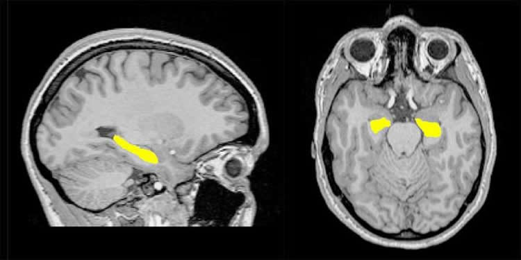

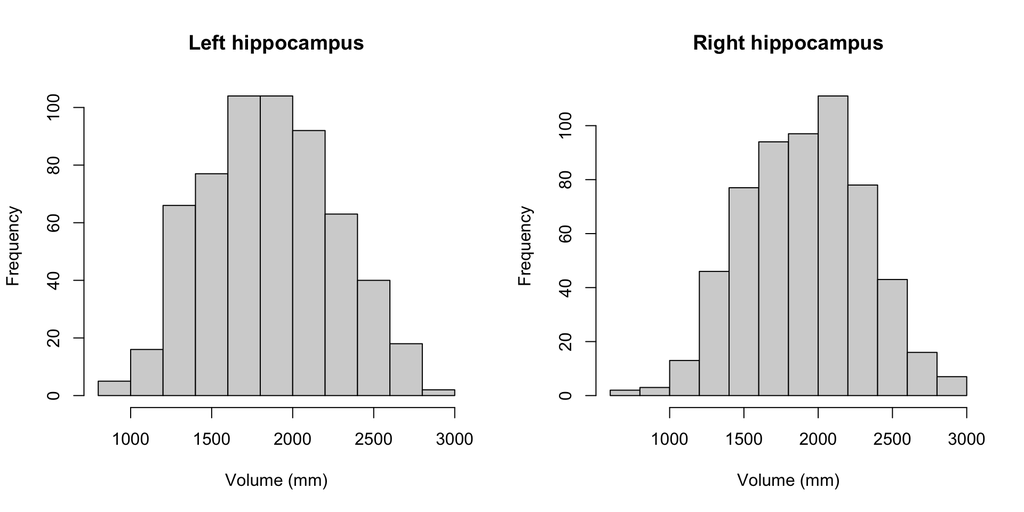

```r
set.seed(12345)
hipp = readRDS('../datasets/adni/hippocampus.rds')
hipp = hipp[!duplicated(hipp$RID),]
layout(matrix(1:2, ncol=2))
hist(hipp$LEFTHIPPO, main='Left hippocampus', xlab='Volume (mm)')
hist(hipp$RIGHTHIPPO, main='Right hippocampus', xlab='Volume (mm)')
```

We’re going to use the ADNI data to study some features of the hippocampus in healthy people and also compare to people with mild cognitive impairment.

These are the research questions

- “In healthy subjects, is there a difference in the size of the left and right hippocampi?”
- “Is there a difference in the size of the left/right hippocampus between HC and those with MCI?”

What is the difference between these hypotheses?

### Single mean/Paired t-test example

- We’ve already constructed some CIs for a single continuous mean.
- A single mean t-test is the testing analog of a single mean CI.
- A “paired” t-test is an example of a single mean hypothesis test.
- Hypothesis testing is convenient for research questions like “Are $A$ and $B$ different?” And not for questions like “What is the difference between $A$ and $B$?”

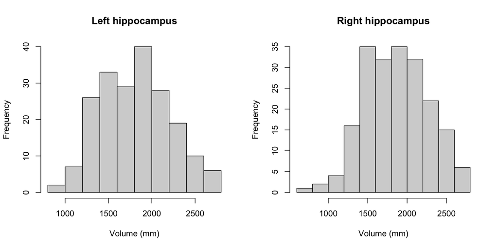

```r
# subsample data to make it more interesting
n = 200
hip = hipp[sample(nrow(hipp), n),]
layout(matrix(1:2, ncol=2))
hist(hip$LEFTHIPPO, main='Left hippocampus', xlab='Volume (mm)')
hist(hip$RIGHTHIPPO, main='Right hippocampus', xlab='Volume (mm)')
```

### Paired data setup

- If $L_i \sim N(\mu_0, \sigma^2_0)$ and $R_i \sim N(\mu_1, \sigma^2_1)$, then $X_i = L_i - R_i \sim N(\delta, \sigma^2)$ where $\delta=\mu_0 - \mu_1$.
- For the paired t-test $\text{Cov}(L_i, R_i) \ne 0$, and contributes to $\sigma^2$.

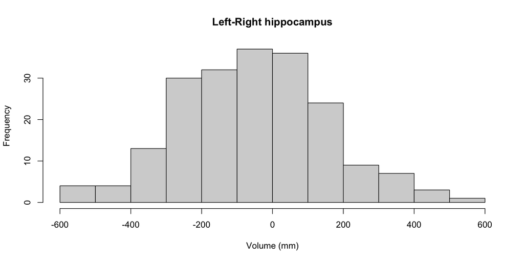

```r
hist(hip$LEFTHIPPO-hip$RIGHTHIPPO, main='Left-Right hippocampus', xlab='Volume (mm)')
```

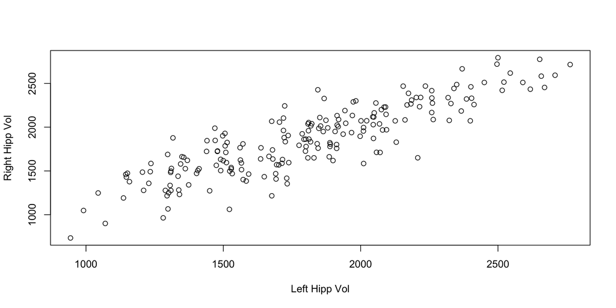

```r
plot(hip$LEFTHIPPO, hip$RIGHTHIPPO, xlab='Left Hipp Vol', ylab='Right Hipp Vol')
```

## Hypothesis testing philosophy

1. State the hypothesis.
2. Set probability threshold for a decision.
3. Compute the test statistic and the p-value.
4. Retain or reject the null.

### Alternative hypotheses

- The alternative hypothesis can be defined as a particular point, called a *simple hypothesis*
  $$H_a: \delta = \delta_a \notin \Delta_0$$
- Most often though, the alternative hypothesis is defined as the compliment to $\Delta_0$, called a *composite hypothesis*.
- For the null $H_0: \delta=0$
  $$H_a: \delta \ne 0.$$
- For the null $H_0: \delta \ge 0$
  $$H_A: \delta < 0.$$

### Hypothesis test probabilities

- The Frequentist framework uses dataset-to-dataset probabilities to make a decision about the hypothesis
- The interpretation is similar to how we constructed confidence intervals.

#### Test statistic version of hypothesis testing

- We rely on the fact that $T = \sqrt{n}(\hat\delta - \delta_0)/\hat \sigma \sim t(n-1)$ if $\delta_0$ is the true value of the parameter.
  - Where $\hat \delta = \bar X$ and $\hat \sigma^2 = (n-1)^{-1} \sum_{i=1}^n (X_i - \bar X)^2$.
  - $T$ is called the **test statistic**.
- In this Frequentist approach, an $\alpha$ level test of $H_0$ chooses a threshold $t_{1-\alpha/2,(n-1)}$ such that $\P(\lvert T \rvert > t_{1-\alpha/2,(n-1)} | H_0) \le \alpha$.
- In words, $\alpha$ is the probability that we observed a statistic larger than $t_{1-\alpha/2,(n-1)}$ under the null.
- We “reject” the null hypothesis if our observed test statistics $\lvert T_{obs} \rvert>t_{1-\alpha/2,(n-1)}$.
- I.e. of the standardized difference between left and right hippocampus is far away from zero in our observed data, that implies that it is probably far away from zero in the population.

### Example: performing the test in the ADNI hippocampus data

- To do this in practice, we specify the null hypothesis, choose the alpha level, and compute the test statistic

```r
X = hip$LEFTHIPPO - hip$RIGHTHIPPO
delta0 = 0
deltaHat = mean(X)
sigmaHat = sd(X)
n = nrow(hip)

# Rejection threshold for t-distributed statistic such the probability it is beyond this value is equal to alpha=0.05
alpha = 0.05
c(lowerTquantile=qt(0.025, df=n-1),
upperTquantile=qt(0.975, df=n-1))
```

```
## lowerTquantile upperTquantile
##      -1.971957       1.971957
```

```r
# test statistic in observed data
c(deltaHat=deltaHat,
sigmaHat = sigmaHat,
Tobs = deltaHat/sigmaHat*sqrt(n))
```

```
##   deltaHat   sigmaHat       Tobs
## -52.176545 204.881850  -3.601528
```

### p-value version of testing

- To do hypothesis testing with a p-value we plug in the observed test statistic into our probability statement

$$p = \P(\lvert T \rvert \ge \lvert T_{obs} \rvert ) \le \P(\lvert T
\rvert > t_{1-\alpha/2,(n-1)} | H_0) \le \alpha$$

- In words, the p-value is the probability we get a statistic at least as large as the one we observed if the null hypothesis is true.

```r
X = hip$LEFTHIPPO - hip$RIGHTHIPPO
delta0 = 0
deltaHat = mean(X)
sigmaHat = sd(X)
n = nrow(hip)

# test statistic in observed data
c(deltaHat=deltaHat,
sigmaHat = sigmaHat,
Tobs = deltaHat/sigmaHat*sqrt(n))
```

```
##   deltaHat   sigmaHat       Tobs
## -52.176545 204.881850  -3.601528
```

```r
pvalue = 2 * pt(-abs(deltaHat/sigmaHat*sqrt(n)), n-1)
```

## Retaining or rejecting the null

- The decision to retain or reject is based on the probability of observing a result as or more extreme than we do in our observed data if the null hypothesis were true.
- the $\alpha$ decides how strict we want to be about rejecting our hypothesis.
- What happens if we decrease $\alpha$?

## Type 1 and type 2 errors

- After making a decision, there are 4 possible outcomes that can occur

|  | Retain $H_0$ | Reject $H_0$ |
| --- | --- | --- |
| $H_0$ True | True negative $\P(\lvert T \rvert< t_{1-\alpha/2,(n-1)} \| H_0)$ | Type 1 error $\P(\lvert T \rvert \ge t_{1-\alpha/2,(n-1)} \| H_0)$ |
| $H_0$ False | Type 2 error $\P(\lvert T \rvert< t_{1-\alpha/2,(n-1)} \| H_a)$ | Power $\P(\lvert T \rvert\ge t_{1-\alpha/2,(n-1)} \| H_a)$ |

### Using the `t.test` function in ADNI

**Methods** In order to test whether left and right hippocampal volumes are equal in healthy older adults, we performed a t-test on the difference in volume for each subject (left - right).

```r
ttest = t.test( hip$LEFTHIPPO - hip$RIGHTHIPPO, alternative = 'two.sided')
ttest
```

```
##
##  One Sample t-test
##
## data:  hip$LEFTHIPPO - hip$RIGHTHIPPO
## t = -3.6015, df = 199, p-value = 0.0003995
## alternative hypothesis: true mean is not equal to 0
## 95 percent confidence interval:
##  -80.74494 -23.60815
## sample estimates:
## mean of x
## -52.17654
```

```r
t.test(hip$LEFTHIPPO, hip$RIGHTHIPPO, paired = TRUE, alternative = 'two.sided')
```

```
##
##  Paired t-test
##
## data:  hip$LEFTHIPPO and hip$RIGHTHIPPO
## t = -3.6015, df = 199, p-value = 0.0003995
## alternative hypothesis: true mean difference is not equal to 0
## 95 percent confidence interval:
##  -80.74494 -23.60815
## sample estimates:
## mean difference
##       -52.17654
```

- For results sections, if the analysis is complicated and will take a paragraph to describe, I might remind the reader what we’re doing in the first sentence of the results.

**Results** We used a one-sample t-test to test whether the difference in left and right hippocampal volume was equal to zero. There was evidence for a difference between left and right hippocampal volumes ($T = \text{-3.6}$, $\mathrm{df}= \text{199}$, $p<0.001$ ) with the left hippocampus being smaller on average ($\text{left-right}=\text{-52.18mm}^3$, confidence interval (CI)= [-80.74, -23.61]).

- More realistically, for a t-test I would just present the result.

**Results** We found evidence for a difference between left and right hippocampal volumes ($T = \text{-3.6}$, $\mathrm{df}= \text{199}$, $p<0.001$ ) with the left hippocampus being smaller on average ($\text{left-right}=\text{-52.18mm}^3$, confidence interval (CI)= [-80.74, -23.61]).

## What is the probability of observing a result this extreme under $H_0: \delta=0$?

$$\P(\vert T\rvert > \text{-3.6015283} \mid H_0) = 2\times
\Phi(\text{-3.6015283})$$
This is the $p$-value. It is conditional on our dataset. Across datasets it is random.

## Parallel between CIs and hypothesis testing

- The hypothesis test for a given $\alpha$ is related to the confidence interval.
- In words, if an $\alpha$ level confidence interval contains a given value, then your data do not have enough evidence to reject that value with an $\alpha$ level test.
- If you reject a value $\delta_0$ with an $\alpha$ level test, then the $\alpha$ level confidence interval does not contain that value.

$$\begin{align*}
1-\alpha & \le 1-\P(\lvert T \rvert\ge t_{1-\alpha/2,(n-1)} \mid
H_0: \delta=\delta_0)\\
& = \P(\vert T\rvert < t_{1-\alpha/2,(n-1)} \mid H_0:
\delta=\delta_0) \\
& = \P(-t_{1-\alpha/2,(n-1)} < T < t_{1-\alpha/2,(n-1)} \mid
H_0: \delta=\delta_0) \\
& = \P(\hat\delta- t_{1-\alpha/2,(n-1)} \times \hat\sigma/\sqrt{n}
< \delta_0 <\hat\delta+ t_{1-\alpha/2,(n-1)}\times
\hat\sigma/\sqrt{n} \mid H_0: \delta=\delta_0)
\end{align*}$$

## Two-tailed hypotheses

- We were using the absolute value because our hypothesis was just that the left and right hippocampus were different.
- *Most commonly, people perform a two-tailed test*
- We can also do a one-tailed hypothesis test

## One-tailed test in the ADNI data

```r
X = hip$LEFTHIPPO - hip$RIGHTHIPPO
delta0 = 0
deltaHat = mean(X)
sigmaHat = sd(X)
n = nrow(hip)

# Rejection threshold for t-distributed statistic such the probability it is beyond this value is equal to alpha=0.05
alpha = 0.05
qt(0.05, df=n-1)
```

```
## [1] -1.652547
```

```r
# test statistic in observed data
deltaHat
```

```
## [1] -52.17654
```

```r
sigmaHat
```

```
## [1] 204.8819
```

```r
deltaHat/sigmaHat*sqrt(n)
```

```
## [1] -3.601528
```

```r
# compute p-value
pt(deltaHat/sigmaHat*sqrt(n), df=n-1)
```

```
## [1] 0.0001997614
```

```r
t.test( hip$LEFTHIPPO, hip$RIGHTHIPPO, paired = TRUE, alternative = 'less')
```

```
##
##  Paired t-test
##
## data:  hip$LEFTHIPPO and hip$RIGHTHIPPO
## t = -3.6015, df = 199, p-value = 0.0001998
## alternative hypothesis: true mean difference is less than 0
## 95 percent confidence interval:
##       -Inf -28.23555
## sample estimates:
## mean difference
##       -52.17654
```

## Practice questions

### Types of errors

Review with questions:

|  | Retain $H_0$ | Reject $H_0$ |
| --- | --- | --- |
| $H_0$ True | True Negative $\P(\lvert T \rvert< t_{1-\alpha/2,(n-1)} \| H_0)$ | 1. _____ $\P(\lvert T \rvert \ge t_{1-\alpha/2,(n-1)} \| H_0)$ |
| $H_0$ False | 2. _____ $\P(\lvert T \rvert< t_{1-\alpha/2,(n-1)} \| H_a)$ | 3. _____ $\P(\lvert T \rvert\ge t_{1-\alpha/2,(n-1)} \| H_a)$ |

- How to compute a test statistic for $H_0: \mu = 2100$?
  $$\frac{(4. \underline{\hspace{2em}} - 5.
  \underline{\hspace{2em}})}{6.\underline{\hspace{2em}} /
  7.\underline{\hspace{2em}}}$$
- 8. How to compute a two-tailed p-value?

### Performing a two-tailed test in the HCP sleep data

- Use a t-test to test whether the population mean of sleep is equal to 8. **Hint** You will have to set the null value equal to 8.
- Write code to reproduce all the output from the t-test command you ran (`t`, `df`, `p-value`, `95 percent confidence interval`, `mean of x`).

```r
hcp = read.csv('../datasets/hcp/hcp.csv')
# amount of sleep variable
# hcp$PSQI_AmtSleep
```

## Example HCP dataset

- In the human connectome project participants perform an emotion recognition task
- We might be interested in comparing whether people are as accurate with identifying fearful faces as they are identifying angry faces

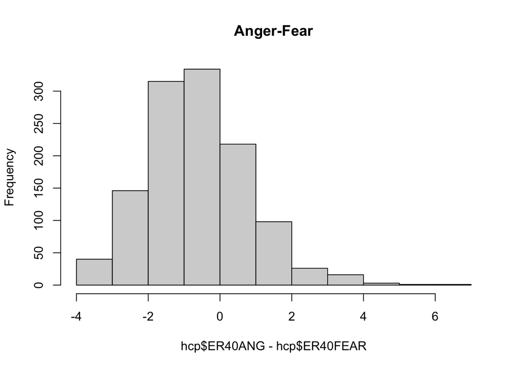

```r
hcp = read.csv('../datasets/hcp/hcp.csv')
hist(hcp$ER40ANG - hcp$ER40FEAR, main='Anger-Fear')
```

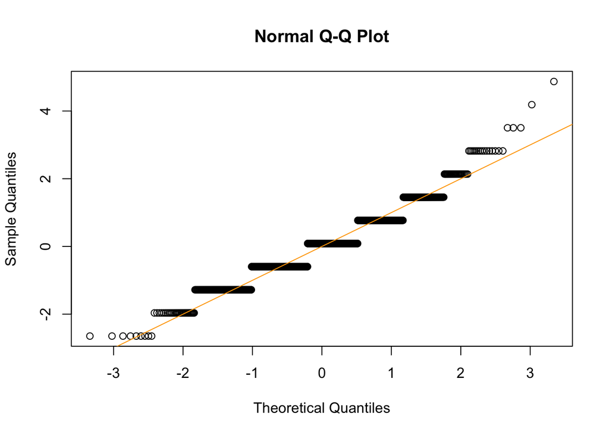

```r
qqnorm(scale(hcp$ER40ANG - hcp$ER40FEAR)); abline(a=0, b=1, col='orange')
```

```r
# two-tailed
t.test(hcp$ER40ANG, hcp$ER40FEAR, paired = TRUE)
```

```
##
##  Paired t-test
##
## data:  hcp$ER40ANG and hcp$ER40FEAR
## t = -3.0013, df = 1197, p-value = 0.002744
## alternative hypothesis: true mean difference is not equal to 0
## 95 percent confidence interval:
##  -0.2098178 -0.0439385
## sample estimates:
## mean difference
##      -0.1268781
```

```r
# one-tail
t.test(hcp$ER40ANG, hcp$ER40FEAR, paired = TRUE, alternative='less')
```

```
##
##  Paired t-test
##
## data:  hcp$ER40ANG and hcp$ER40FEAR
## t = -3.0013, df = 1197, p-value = 0.001372
## alternative hypothesis: true mean difference is less than 0
## 95 percent confidence interval:
##         -Inf -0.05728953
## sample estimates:
## mean difference
##      -0.1268781
```

### One-tailed hypotheses

- We can define one tailed hypotheses if we believe the result should be in a particular direction.
- E.g. if my null hypothesis is that the Anger emotion identification is at least as accurate as fearful.
  $$H_0: \E A_i - \E F_i = \delta \ge 0$$
- Because there is not a single value for $\delta_0$, we choose a value that is most conservative
- This usually occurs at the boundary of the null set, in this case $\delta_0 = 0$.
- So the test statistic is (same as before).
  $$T = \frac{\hat \delta}{ \hat \sigma/\sqrt{n}}$$
- For our test, only smaller values of the test statistic are evidence against the null (values larger than zero imply $\hat\delta>0$, which is in the null set.
- So we choose the rejection threshold $t_{\alpha,(n-1)}$, so that
  $$\P(T<t_{\alpha,(n-1)}) = \alpha$$
- When our observed test statistics $T_{obs}<t_{\alpha,(n-1)}$ we reject the null
- Alternatively, we can compute the p-value
  $$p = \P(T<T_{obs})$$
  and reject when $p<\alpha$

## Alternatives to T-test

### Z-test

- If the underlying data are not normally distributed, then we use the CLT approximation
  $$\frac{\bar X_n - \delta_0}{\hat\sigma/\sqrt{n}} \approx_D Z \sim N(0,1)$$
- Using the Lindeberg-Feller Theorem also allows us to relax the identicality assumption.
- We can then do all the same stuff we did with hypothesis testing for the single mean.
- A natural question is, which of the two tests performs better? We can use simulations to answer this question.

## Simulations to evaluate hypothesis testing

What are the metrics we care about, here?

- Type 1 error rate $\P(\vert T \rvert > t_{1-\alpha/2,(n-1)} )$. By design it should be $\alpha=0.05$.
  - Another way to check type 1 error rate is using the p-value.
    $$\begin{align*}
    \alpha = \P\{\vert T \rvert > t_{1-\alpha/2,(n-1)} \} & =
    \P(2\times pt(\vert T \rvert, n-1) > 2 \times pt(t_{1-\alpha/2,(n-1)}
    )\}\\
    & = \P(p < \alpha)
    \end{align*}$$
- What does this probability mean? It is about dataset-to-dataset variability.
- A Z-test is the same thing with the Z-distribution as the reference distribution.
- Power is another metric we care about – we have to pick the alternative.
- How to simulate non-normality? Synthetically sampling data from the gamma distribution.
- What are the parameters? `n`, `alpha`, `nsim`, the density function I will use for sampling (gamma distribution)

|  | Retain $H_0$ | Reject $H_0$ |
| --- | --- | --- |
| $H_0$ True | True negative $\P(\lvert T \rvert< t_{1-\alpha/2,(n-1)} \| H_0)$ | Type 1 error $\P(\lvert T \rvert \ge t_{1-\alpha/2,(n-1)} \| H_0)$ |
| $H_0$ False | Type 2 error $\P(\lvert T \rvert< t_{1-\alpha/2,(n-1)} \| H_a)$ | Power $\P(\lvert T \rvert\ge t_{1-\alpha/2,(n-1)} \| H_a)$ |

### Research question for the simulations: Are t-test and z-test affected by data that have a nonnormal distribution?

- $X_i \sim Gamma(\alpha,\beta)$ (iid).
- T-test assumes $X_i\sim N(\mu, \sigma^2)$ (violated).
- Z-test is approximation, no assumption on distribution of $X_i$.
- Which performs better?

```r
set.seed(12345)

# creating blank output table
mu = 0
ns = seq(10, 100, length.out=10)
alphas = c(0.01, 0.05, 0.1)
nsim = 1000
results = expand.grid( n=ns, alpha=alphas)
colNames = c('t-test type 1 error', 'z-test type 1 error')
results[, colNames ] = NA



### Loop through parameter settings and run simulations
# (Potential states of the world)
# loop through "n" only instead
for(n in ns){
   # draw one sample of size n from our random variable nsim times
   settingResults = matrix(NA, ncol=2, nrow=nsim)
   for(sim in 1:nsim){
     # generate the sample
     simulatedData = mu + (rgamma(n, shape = 1.2, rate = 5) - 1.2/5)/sqrt(1.2)*5

     tResult = t.test(simulatedData)
     # p-value for the t-test
     settingResults[sim, 1] = tResult$p.value
    # p-value for the Z-test
     settingResults[sim, 2] = 2*pnorm(abs(tResult$statistic), lower.tail = FALSE)
   }
   # compute type 1 error rate across the simulations
   results[results$n==n, c('t-test type 1 error', 'z-test type 1 error')] = t(sapply(results[ results$n==n,'alpha'], function(a) colMeans(settingResults<a, na.rm=TRUE)))
}
```

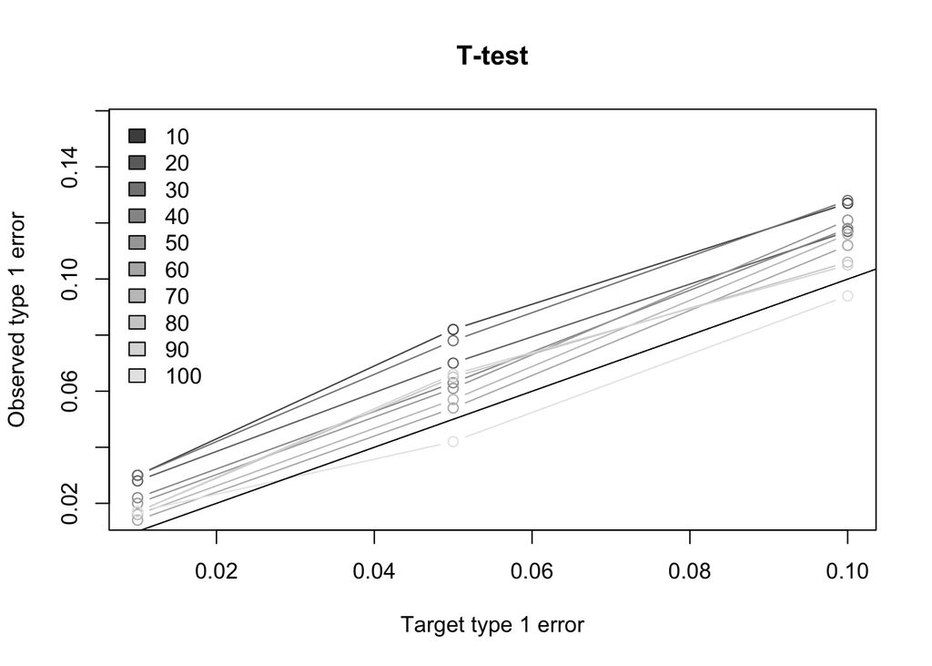

```r
# plotting simulation results
cols = gray.colors(length(ns))

# T-test
plot(results$alpha, results$`z-test type 1 error`, type='n', xlab='Target type 1 error', ylab='Observed type 1 error', main='T-test')
trash = by(results, results$n, function(df) points(df$alpha, df$`t-test type 1 error`, type='b', col=cols[which(ns %in% df$n)]))
abline(a=0,b=1)
legend('topleft', fill=cols, legend=ns, bty='n')
```

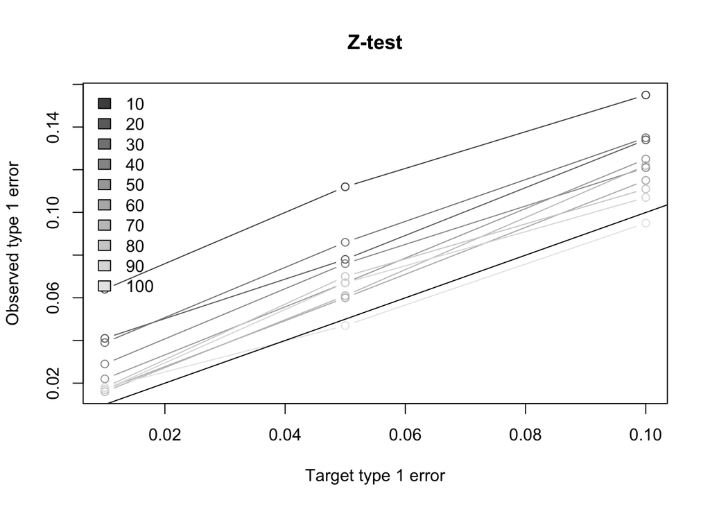

```r
# Z-test
plot(results$alpha, results$`z-test type 1 error`, type='n', xlab='Target type 1 error', ylab='Observed type 1 error', main='Z-test')
trash = by(results, results$n, function(df) points(df$alpha, df$`z-test type 1 error`, type='b', col=cols[which(ns %in% df$n)]))
abline(a=0,b=1)
legend('topleft', fill=cols, legend=ns, bty='n')
```

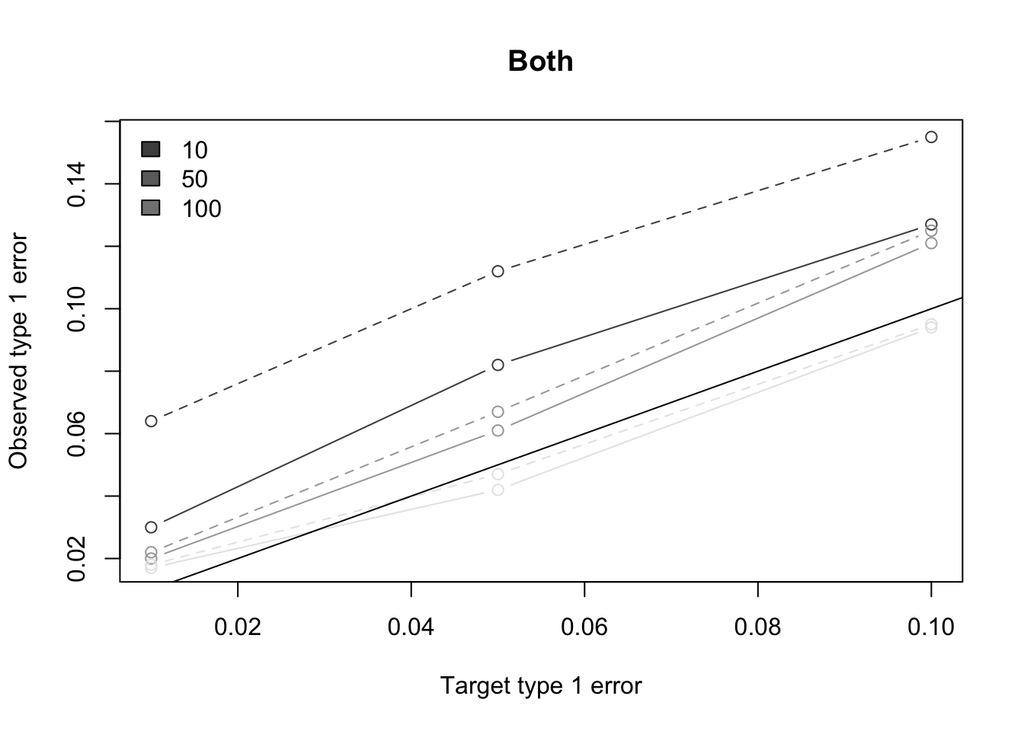

```r
# Both
results = results[results$n %in% c(10, 50, 100),]
plot(results$alpha, results$`z-test type 1 error`, type='n', xlab='Target type 1 error', ylab='Observed type 1 error', main='Both')
trash = by(results, results$n, function(df) points(df$alpha, df$`t-test type 1 error`, type='b', col=cols[which(ns %in% df$n)]))
trash = by(results, results$n, function(df) points(df$alpha, df$`z-test type 1 error`, type='b', col=cols[which(ns %in% df$n)], lty=2))
abline(a=0,b=1)
legend('topleft', fill=cols, legend=unique(results$n), bty='n')
```

## (Frequentist) Confidence intervals for two means

- We will study mean differences between two groups.
- We’ll construct some confidence intervals for a difference in means
- The concepts are the same, with a few more complexities

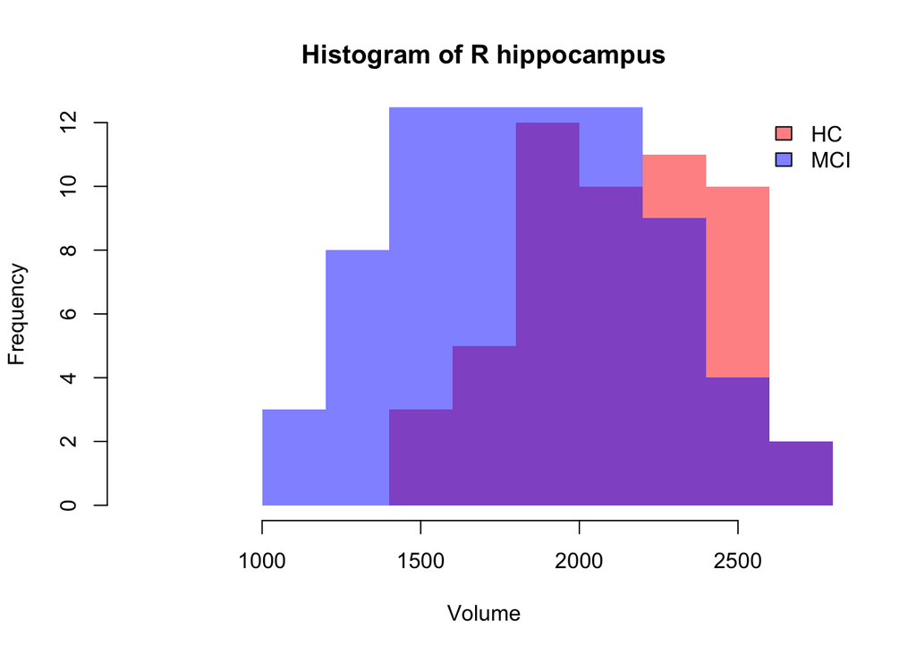

[figure not shown]

```r
histinfo = hist(hip$RIGHTHIPPO, plot = FALSE)
hist(hip$RIGHTHIPPO[ hip$DX=='HC'], breaks = histinfo$breaks, main="Histogram of R hippocampus",
     xlab="Volume", col=rgb(1,0,0,.5), border=NA)
hist(hip$RIGHTHIPPO[ hip$DX=='MCI'], breaks=histinfo$breaks, col=rgb(0,0,1,.5), add=TRUE, border=NA)
legend('topright', fill=c(rgb(1,0,0,.5), rgb(0,0,1,.5)), legend=c('HC', 'MCI'), bty='n')
```

- “Is there a difference in the size of the left/right hippocampus between HC and those with MCI?”
- Let $\mu_h$ denote the mean for healthy participants and $\mu_p$ denote the mean for patients.

### Mean differences

- Here is the context:
  $$\begin{align*}
  Y_i & \sim N(\mu_0, \sigma^2_h) \text{ for $i=1,\ldots,n_h$}\\
  Y_i & \sim N(\mu_1, \sigma^2_p) \text{ for $i=n_h+1, \ldots,
  n_h+n_p$}
  \end{align*}$$
  where
- $n_h$ – number in group 0 (females).
- $n_p$ – number in group 1 (males).
- $n := n_h + n_p$.
- $\delta := \mu_p - \mu_h$.
- We’ll start by assuming equal variances $\sigma^2_h = \sigma^2_p$.
- We will start off simple and relax some assumptions.

### Hypothesis testing philosophy (recap)

1. State the hypothesis.
2. Set probability threshold for a decision.
3. Compute the test statistic and the p-value.
4. Retain or reject the null.

#### Null hypothesis

What’s the null hypothesis?

#### Alternative hypotheses

What’s the alternative hypothesis?

#### Probability of rejection

- Pick a probability for rejection. $\alpha=$

## Wald statistic for two means

- The Wald statistic with known variance is defined as $(\hat \delta - \delta)/\sqrt{\text{Var}(\hat\delta)}$.
- We need to find $\hat \delta$ and $\widehat{\text{Var}}(\hat\delta)$, just like we did for the single mean example.
- Derive the estimators.

### What is the distribution of the Wald statistic?

- What is the variance of each mean estimator?
  $$\text{Var}(\hat \mu_h) = \frac{\sigma^2_h}{n_h}$$
- What is the variance of $\hat\delta$
  $$\text{Var}(\hat \delta) = n_h^{-1} \sigma^2_h + n_p^{-1} \sigma^2_p =
  (n_h^{-1} + n_p^{-1})\sigma^2$$
  (last line assumes equal variance)
- Under normality with known variance then a Z-test statistic is
  $$\frac{(\hat \delta - \delta)}{\sqrt{(n_h^{-1} + n_p^{-1})\sigma^2}} \sim
  N(0, 1)$$
- As is usual, the variance is not known.

What is an estimator of variance?

- Variance for $\widehat{\text{Var}}(\hat\mu_h) = \hat\sigma^2_h/n_h$
  $$\hat\sigma^2_h= (n_h-1)^{-1}\sum_{i=1}^{n_h}(X_i - \hat\mu_h)^2$$
- Variance estimator for $\hat \mu_1$ is the same under equal variance assumption.
- Equal variance *pooled variance* estimator
  $$\hat\sigma^2 = \frac{ \sum_{i=1}^{n_h}(X_i - \hat\mu_h)^2
  + \sum_{i=1}^{n_p}(X_i - \hat\mu_p)^2}{ (n_h-1) + (n_p-1)}$$
- This gives the usual form of the test statistic that we can use for confidence intervals and testing, except now with flavors of two means.
  $$\frac{\{ \hat\delta-\delta \}}{\sqrt{(n_h^{-1} + n_p^{-1})\hat\sigma^2}}
  = \frac{\{ (\hat\mu_h - \hat\mu_p)-(\mu_h - \mu_p)\}}{\sqrt{(n_h^{-1} +
  n_p^{-1})\hat\sigma^2}}$$

```r
nh = sum(hip$DX=='HC')
np = sum(hip$DX=='MCI')
hc = hip$RIGHTHIPPO[hip$DX=='HC']
mci = hip$RIGHTHIPPO[hip$DX=='MCI']
muhHat = mean(hc)
mupHat = mean(mci)
# variance of the X_i's
pooledVar = (var(hc)*(nh-1) + var(mci)*(np-1))/(nh+np-2)


Tstat = (mupHat-muhHat)/sqrt( (1/nh + 1/np)*pooledVar )

TtestResults = t.test(hc, mci, var.equal = TRUE)

# assuming test statistic under H_0 is t(nf+nm-2)
alpha = 0.05
qt(1-alpha/2, df = nh+np-2)
```

```
## [1] 1.975799
```

```r
pt(abs(Tstat), df = nh+np-2, lower.tail=FALSE) * 2
```

```
## [1] 2.145791e-07
```

```r
# Under H_0, T (our test statistic) ~ t(nf +nm-2), T_obs=abs(4.2596)
# all do the same thing
#2*(1-pt(, df = nf+nm-2))
#2*(pt(, df = nf+nm-2, lower.tail = FALSE))
#pt(, df = nf+nm-2, lower.tail = TRUE) + pt(, df = nf+nm-2, lower.tail = FALSE)
```

### Assumptions we’ve made for equal variance two-sample t-test so far

- Equal variance

## Unequal variances: Welch’s t-test

### Unequal variance formula

- When the variances are not equal, the variance of $\hat\delta$ is
  $$\sigma_{\hat\delta}^2 = n_0^{-1} \sigma^2_0 + n_1^{-1} \sigma^2_1$$

$$\begin{align*}
\hat \sigma^2_0 & = (n_0-1)^{-1} \sum_{i=1}^{n_0}(X_i - \hat\mu_0)^2
\end{align*}$$

Then, plugging-in to get a variance estimator for $\hat\delta$
$$\hat\sigma^2 = n_0^{-1} \hat\sigma^2_0 + n_1^{-1} \hat\sigma^2_1$$

### Unequal variances test statistic

- What is the distribution of
  $$\frac{(\hat \delta - \delta)}{\sqrt{n_0^{-1} \hat\sigma^2_0 + n_1^{-1}
  \hat\sigma^2_1}}$$
- Nobody knows the distribution this statistic.

### Satterthwaite approximation

- Satterthwaite came-up with a way to approximate the distribution of $\hat \sigma^2 =n_0^{-1} \hat\sigma^2_0 + n_1^{-1} \hat\sigma^2_1$ with a chi-square distribution
- Note that $\E \hat\sigma^2 = \sigma^2$
- This is the general premise:
  - $(n_0-1)\hat\sigma^2_0/\sigma_0^2 \sim \chi^2(n_0-1)$, and same for $\hat\sigma^2_1$
  - Imagine if we could approximate the distribution of $\nu \frac{\hat\sigma^2}{\sigma^2}$ with a chi-squared distribution on $\nu$ degrees of freedom, then
    $$\frac{(\hat \delta - \delta)/\sigma^2}{ \sqrt{\nu
    \hat\sigma^2/\sigma^2/\nu}} \sim t(\nu) \text{ (approximately) },$$
    because $\nu \hat\sigma^2/\sigma^2 \sim \chi^2(\nu)$
- How do we find $\nu$?
  - Satterthwaite proposed finding $\nu$ by matching the mean and variance of $\nu W/\sigma^2$ to a chi-squared distribution and solving for $\nu$.
  - That yields the formula
    $$\nu = \frac{ \left(n_0^{-1}\hat\sigma^2_0 + n_1^{-1}\hat\sigma^2_1
    \right)}{n_0^{-2}(n_0-1)\hat\sigma^4_0 + n_1^{-2}(n_1-1)\hat\sigma^4_1}$$
  - Welch was the one who did it for the t-test.
  - It’s a very ugly formula, but the approximation works very well, such that it is the default t-test in `R`.

```r
nh = sum(hip$DX=='HC')
np = sum(hip$DX=='MCI')
hc = hip$RIGHTHIPPO[hip$DX=='HC']
mci = hip$RIGHTHIPPO[hip$DX=='MCI']
muhHat = mean(hc)
mupHat = mean(mci)

# This is no longer the correct variance estimator
pooledVar = (var(hc)*(nh-1) + var(mci)*(np-1))/(nh+np-2)
Tstat = (muhHat-mupHat)/sqrt((1/nh + 1/np)*pooledVar )
satterTstat = (muhHat-mupHat) / sqrt(var(hc)/nh + var(mci)/np)

TtestResults = t.test(hc, mci)

# assuming test statistic under H_0 is t(nf+nm-2)
alpha = 0.05
qt(1-alpha/2, df = nh+np-2)
```

```
## [1] 1.975799
```

```r
# p-value is equal to the probability of a result as or more extreme as T_obs
#T_obs = abs(-4.2731)
#2*pt(abs(T_obs), df=78.365, lower.tail=FALSE)

# assuming test statistic under H_0 is t(nf+nm-2)
#alpha = 0.05
#qt(1-alpha/2, df = 78.365)
```

## Mean difference in linear regression